# Model Basics

Exercises I

2017-11-29

### Exercises

1.What happens if you repeat the analysis of `sim2` using a model without an intercept. What happens to the model equation? What happens to the predictions?

```r
mod1 <- lm(y~x - 1, data = sim2)
mod2 <- lm(y~x, data = sim2)
mod1$coefficients
mod2$coefficients

grid1 <- sim2 %>%
  data_grid(x)%>%
  gather_predictions(mod1,mod2)
grid1
```

[output not shown]

The equation will have no intercept term.

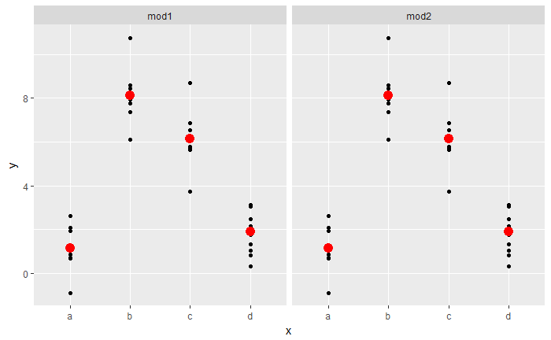

```r
sim2 %>%
  ggplot(aes(x))+
  geom_point(aes(y=y))+
  geom_point(data = grid1, aes(y = pred),color = "red",size = 4)+
  facet_grid(~model)
```

However, the prediction doesn’t change. Categorical predictors are not affected by the removal of intercept terms.

2.Use `model_matrix()` to explore the equations generated for the models I fit to `sim3` and `sim4`. Why is `*` a good shorthand for interaction?

```r
# sim3
model_matrix(data = sim3, y ~ x1 + x2)
```

| (Intercept) | x1 | x2b | x2c | x2d |
| --- | --- | --- | --- | --- |
| 1 | 1 | 0 | 0 | 0 |
| 1 | 1 | 0 | 0 | 0 |
| 1 | 1 | 0 | 0 | 0 |
| 1 | 1 | 1 | 0 | 0 |
| 1 | 1 | 1 | 0 | 0 |
| 1 | 1 | 1 | 0 | 0 |
| 1 | 1 | 0 | 1 | 0 |
| 1 | 1 | 0 | 1 | 0 |
| 1 | 1 | 0 | 1 | 0 |
| 1 | 1 | 0 | 0 | 1 |

[output cut: 110 more lines]

```r
model_matrix(data = sim3, y ~ x1 * x2)
```

| (Intercept) | x1 | x2b | x2c | x2d | x1:x2b | x1:x2c | x1:x2d |
| --- | --- | --- | --- | --- | --- | --- | --- |
| 1 | 1 | 0 | 0 | 0 | 0 | 0 | 0 |
| 1 | 1 | 0 | 0 | 0 | 0 | 0 | 0 |
| 1 | 1 | 0 | 0 | 0 | 0 | 0 | 0 |
| 1 | 1 | 1 | 0 | 0 | 1 | 0 | 0 |
| 1 | 1 | 1 | 0 | 0 | 1 | 0 | 0 |
| 1 | 1 | 1 | 0 | 0 | 1 | 0 | 0 |
| 1 | 1 | 0 | 1 | 0 | 0 | 1 | 0 |
| 1 | 1 | 0 | 1 | 0 | 0 | 1 | 0 |
| 1 | 1 | 0 | 1 | 0 | 0 | 1 | 0 |
| 1 | 1 | 0 | 0 | 1 | 0 | 0 | 1 |

[output cut: 110 more lines]

```r
# sim4
model_matrix(data = sim4, y ~ x1 + x2)
```

| (Intercept) | x1 | x2 |
| --- | --- | --- |
| 1 | -1.0000000 | -1.0000000 |
| 1 | -1.0000000 | -1.0000000 |
| 1 | -1.0000000 | -1.0000000 |
| 1 | -1.0000000 | -0.7777778 |
| 1 | -1.0000000 | -0.7777778 |
| 1 | -1.0000000 | -0.7777778 |
| 1 | -1.0000000 | -0.5555556 |
| 1 | -1.0000000 | -0.5555556 |
| 1 | -1.0000000 | -0.5555556 |
| 1 | -1.0000000 | -0.3333333 |

[output cut: 290 more lines]

```r
#model_matrix(data = sim4, y ~ x1 + x2 + I(x1*x2))
model_matrix(data = sim4, y ~ x1 * x2)
```

| (Intercept) | x1 | x2 | x1:x2 |
| --- | --- | --- | --- |
| 1 | -1.0000000 | -1.0000000 | 1.00000000 |
| 1 | -1.0000000 | -1.0000000 | 1.00000000 |
| 1 | -1.0000000 | -1.0000000 | 1.00000000 |
| 1 | -1.0000000 | -0.7777778 | 0.77777778 |
| 1 | -1.0000000 | -0.7777778 | 0.77777778 |
| 1 | -1.0000000 | -0.7777778 | 0.77777778 |
| 1 | -1.0000000 | -0.5555556 | 0.55555556 |
| 1 | -1.0000000 | -0.5555556 | 0.55555556 |
| 1 | -1.0000000 | -0.5555556 | 0.55555556 |
| 1 | -1.0000000 | -0.3333333 | 0.33333333 |

[output cut: 290 more lines]

`*` is good because 1. It is simple and efficient to treat categorical predictors, which is tedious to do using `+`. Or even impossible? 2. It is simple to create interaction term for continuous varaibles too.

3. Using the basic principles, convert the formulas in the following two models into functions. (Hint: start by converting the categorical variable into 0-1 variables.)

```r
mod1 <- lm(y ~ x1 + x2, data = sim3)
mod2 <- lm(y ~ x1 * x2, data = sim3)
```

Convert `x2` to bianry variables. Thanks to this StackOverflow [answer](https://stackoverflow.com/a/24374192)

```r
library(tidyr)
sim3 <- sim3 %>%
  mutate(present = 1)%>%
  spread(x2,present,fill=0)
```

```r
mod1 <- lm(y ~ x1 + a + b + c + d, data = sim3)
mod2 <- lm(y ~ x1*a*b*c*d, data = sim3)
# all possible combinations
head(model.matrix(data = sim3, y ~ x1*a*b*c*d))
```

[output not shown]

4. For `sim4`, which of `mod1` and `mod2` is better? I think `mod2` does a slightly better job at removing patterns, but it’s pretty subtle. Can you come up with a plot to support my claim?

Let’s check the distribution of the residuals.

```r
mod1 <- lm(y ~ x1 + x2, data = sim4)
mod2 <- lm(y ~ x1 * x2, data = sim4)
grid <- sim4 %>%
  data_grid(x1,x2)
grid <- grid %>%
  gather_predictions(mod1, mod2)
sim4 <- sim4 %>% gather_residuals(mod1,mod2)
```

Plot the residual’s distribution

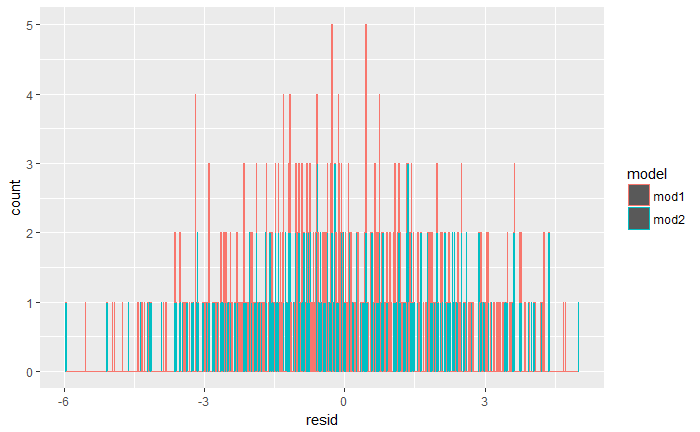

```r
med1 <- median((sim4 %>% filter(model == "mod1"))$resid)
med2 <- median((sim4 %>% filter(model == "mod2"))$resid)
ggplot(sim4, aes(resid,color = model))+
  geom_histogram(binwidth = 0.01,position = "stack")
```

From the exploratory analysis, we may plot the residue as a function of `x1`

```r
sim4 %>% group_by(model)%>%
  summarize(mean_abs_resid = mean(abs(resid)))
```

| model | mean_abs_resid |
| --- | --- |
| mod1 | 1.708070 |
| mod2 | 1.670054 |

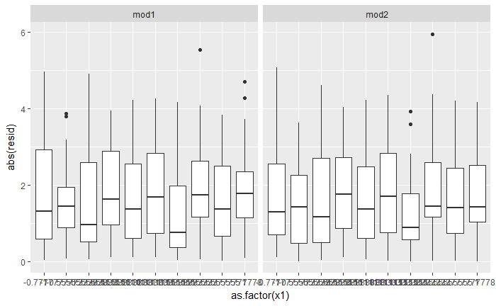

```r
# the mean of absolute residual for mod2 is smaller for mod1
sim4 %>%
  ggplot(aes(y=abs(resid),x = as.factor(x1)))+
  geom_boxplot()+
  facet_grid(~model)
```

It is not that obvious but visually detectable.